# Взаимосвязи в компании: отчет

Барышев Матвей, mibaryshev

Загрузка данных

```r
library(ggraph)
library(igraphdata)
library(igraph)
library(stringr)
data(enron)
library(lubridate)
source("~/shared/minor2_2022/2-tm-net/hw/personalTask.R")
start_date = hw_net_get_start_date()
# определяем конечную точку месяца
last_date = start_date + dmonths(1)
time = as_date(as_datetime(E(enron)$Time))
# убираем вершины раньше начальной точки и позже конечной
net = enron %>% delete_edges(E(enron)[time < start_date | time > last_date])
# убираем связи вершины самой с собой (согласно данным, иногда люди себя в копию ставят)
net = simplify(net, remove.multiple = F)
# убираем обособленные вершины
net = net %>% delete_vertices(V(net)[degree(net) == 0])
```

Анализируются данные с 2000-07-01 15:00:00 по 2000-08-01 01:30:00

## Описание сети

Данная сеть представляет собой данные о переписках 95 сотрудников в компании Enron в период с 1 июля 2000 года до 1 августа 2000 года. Сеть является направленной, потому что ребро обозначает отправленное письмо от отправителя к получателям. Всего в нашей сети 2775 рёбер. Следовательно, за данный период сотрудниками было отправлено 2775 писем.

```r
net
```

```
## IGRAPH 30cf99e D--- 95 2775 -- Enron email network
## + attr: LDC_names (g/c), LDC_desc (g/c), name (g/c), Citation (g/c),
## | Email (v/c), Name (v/c), Note (v/c), Time (e/c), Reciptype (e/c),
## | Topic (e/n), LDC_topic (e/n)
## + edges from 30cf99e:
##  [1] 36-> 2 36-> 2 36-> 2  7->41  7->41  7->41  7->41  7->48  7->48  7->48
## [11]  7->48  7->81  7->81  7->81  7->81 18->59 18->59 18->59 18->59 18->69
## [21] 18->69 18->69 18->69 52->58 52->58 19->16 19->16 19->16 19->16 58->52
## [31] 58->52 58->52 58->52 52->58 52->58 52->58 52->58 58->71 58->71 82->34
## [41] 82->34 82->34 82->34 82->34 82->34 82->34 82->34 69->18 69->18 69->18
## [51] 13->38 13->38 13->38 13->38 90->17 90->17 90->33 90->33 90->55 90->55
## + ... omitted several edges
```

### Выявление значимых вершин

Для начала выявим значимые вершины с помощью различных мер центральности.

**Использованные меры центральности: degree centrality, betweenness centrality**

1. степень вершин (degree centrality)

Выделим на визуализации вершины с самой большой степенью.

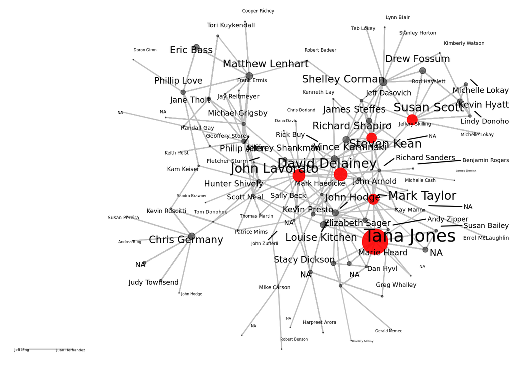

```r
ggraph(net) +
    geom_edge_link(color = "grey", alpha = 0.7) +
    geom_node_point(color = dplyr::case_when(degree(net) > 200 ~ "red", TRUE ~ "black"),
                    size = degree(net)/50,
                    alpha = dplyr::case_when(degree(net) > 200 ~ 0.9, TRUE ~ 0.5)) +
    geom_node_text(aes(label=Name, size = degree(net)/100), show.legend = FALSE, nudge_x = 0.1, nudge_y = 0.1, repel = TRUE)  +
    theme_void()
```

2. центральность по посредничеству (betweenness centrality)

Выделим на визуализации вершины с самой большой центральностью по посредничеству.

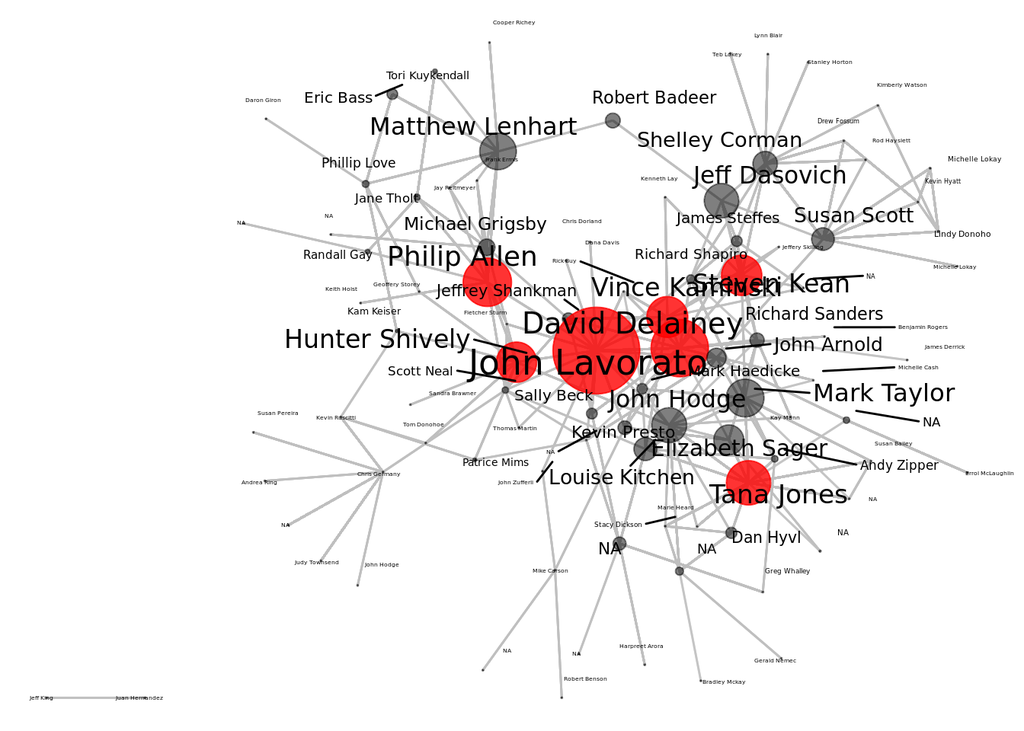

```r
ggraph(net) +
    geom_edge_link(color = "grey", alpha = 0.7) +
    geom_node_point(color = dplyr::case_when(betweenness(net) > 600 ~ "red", TRUE ~ "black"),
                    size = betweenness(net)/70,
                    alpha = dplyr::case_when(betweenness(net) > 600 ~ 0.8, TRUE ~ 0.5)) +
    geom_node_text(aes(label=Name, size = betweenness(net)/100), show.legend = FALSE, nudge_x = 0.1, nudge_y = 0.1, repel = TRUE)  +
  theme_void()
```

Из данной визуализации можно сделать вывод, что через сотрудника с именем John Lavorato через email проходило больше всего информации, так как его betweenness centrality самая большая. Также, большая центральность по посредничеству заметна у вершин близких к John Lavorato. Можно предположить, что эти люди обеспечивают связь между разными филиалами или отделами компании, так как через них проходят большинство кратчайших путей.

3. показатель ассортативности

Вычислим ассортативность для узлов нашей сети по занимаемой должности.

```r
vertices = data.frame(name = V(net)$Name, note = V(net)$Note)
vertices = vertices %>% dplyr::mutate(note = str_extract(note, "[A-Za-z ]*[^,]"))
vertices$note = ifelse(vertices$note == "NA", "Employee", V(net)$Note)

assortativity_nominal(net, vertices$note, directed = T)
```

```
## [1] 0
```

Получили ответ 0. Следовательно, работники нашей компании не имеют определённой тенденции в отправке писем. Сотрудники отправляют друг другу письма без привязки к определённой должности.

### Выявление сообществ

**Использованные меры выделения сообществ: edge betweenness community, walktrap community**

В ходе анализа было использовано 2 алгоритма выявления сообществ: Girvan–Newman algorithm и Walktrap algorithm. Первый заключается в последовательном удалении связей в порядке убывания показателей битвидности ребер (edge betweenness scores), то есть числа кратчайших путей, проходящих по рассматриваемому ребру. А второй в случайном “блуждании” по графу.

Сравнив полученные сообщества по модулярности, видно что разбиение по walktrap лучше.

```r
coms_eb = edge.betweenness.community(net)
coms_wt = walktrap.community(net)

modularity(coms_eb)
```

```
## [1] 0.5764704
```

```r
modularity(coms_wt)
```

```
## [1] 0.648177
```

Визуализируем полученные с помощью алгоритма Walktrap сообщества.

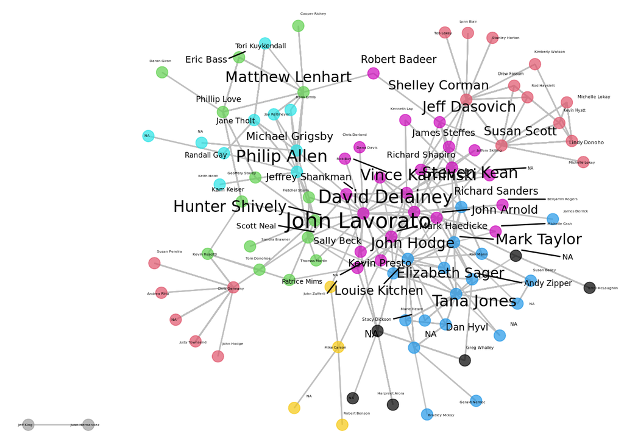

```r
ggraph(net) +
    geom_edge_link(color = "grey", alpha = 0.7) +
    geom_node_point(color = membership(coms_wt), size = 4, alpha = 0.7) +
    geom_node_text(aes(label=Name, size = betweenness(net)/100), show.legend = FALSE, nudge_x = 0.1, nudge_y = 0.1, repel = TRUE)  +
  theme_void()
```

Алгоритм Walktrap выделил в нашей сети 10 сообществ с достаточно хорошим показателем модулярности (0.65). Из данного разбиения можно сделать вывод, что в компании достаточно точно прослеживается разделение на сообщества. Возможно, полученное разбиение иллюстрирует разделение сотрудников на отделы или филиалы внутри компании. Из выше представленных расчётов и расположения на визуализации я могу предположить, что фиолетовое сообщество в центре графа относится к начальству компании, так как оно тесно связано практически со всеми остальными сообществами и в него входят вершины с высокой битвидностью.

### Исследовательские вопросы

**Вопрос 1: Правда ли, что руководство компании (CEO, President, Vice President) сосредоточенно в одном сообществе, включающем John Lavorato и находящемся по центру графа**

Получим датасет из имён работников, их должности и выделенного сообщества.

```r
vertices = data.frame(name = V(net)$Name, note = V(net)$Note, community = membership(coms_wt)[])
```

Определим номер сообщества, в которое входит John Lavorato.

```r
head_community_number = vertices %>% dplyr::filter(name == "John Lavorato")
head_community_number = head_community_number$community
```

Построим диаграмму распределения должностей в данном сообществе.

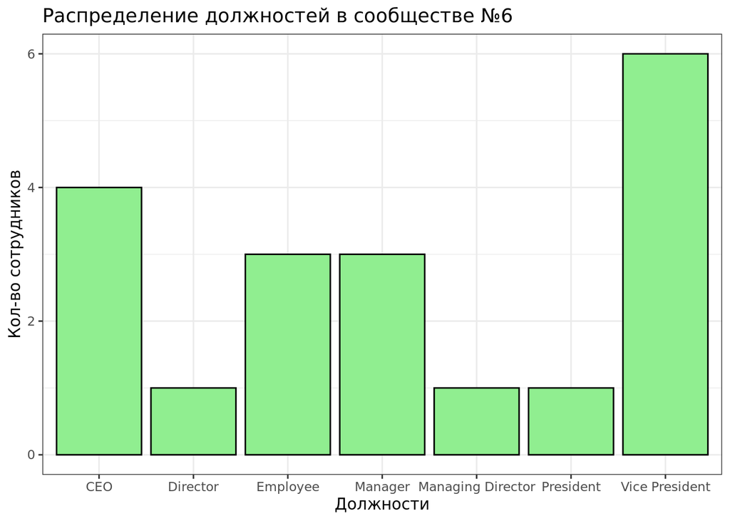

```r
vertices = vertices %>% dplyr::filter(community == head_community_number) %>% dplyr::filter(note != "NA")
vertices = vertices %>% dplyr::mutate(note = str_extract(note, "[A-Za-z ]*[^,]"))

ggplot(vertices) +
  geom_bar(aes(note), color = "black", fill = "lightgreen") +
  xlab("Должности") +
  ylab("Кол-во сотрудников") +
  ggtitle(str_c("Распределение должностей в сообществе №", as.character(head_community_number))) +
  theme_bw()
```

Из данного графика видно, что в сообществе присутствует большое количество людей с высокими должностями, такими как CEO и Vice President.

Для наглядности стоит взглянуть на распределение должностей в других сообществах.

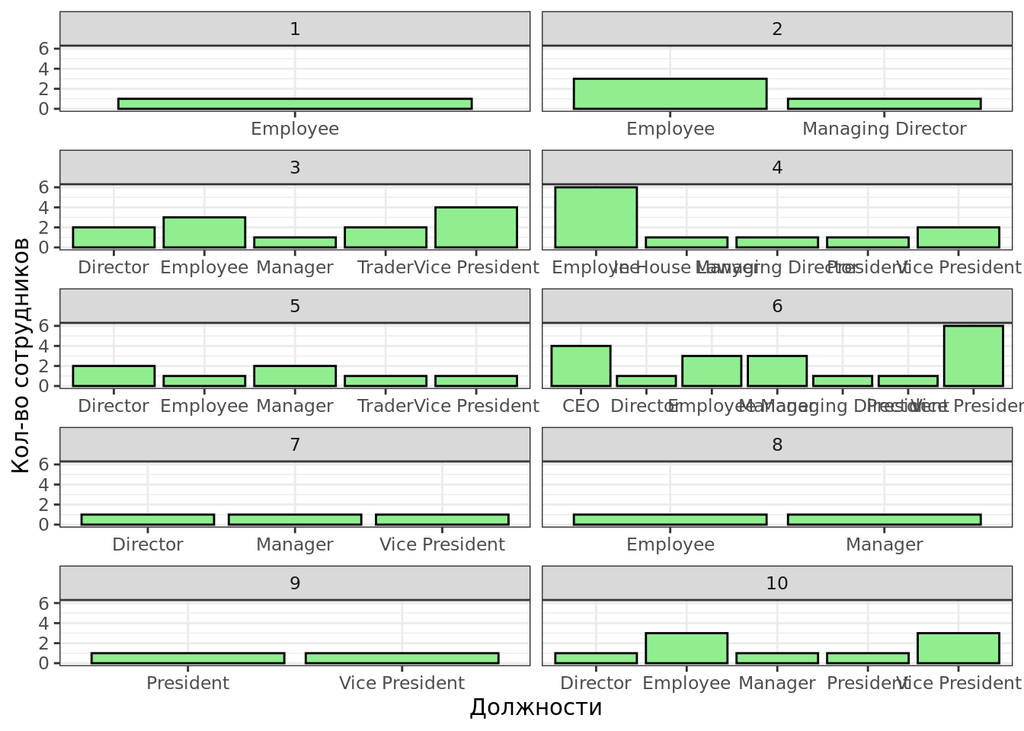

```r
vertices = data.frame(name = V(net)$Name, note = V(net)$Note, community = membership(coms_wt)[])
vertices = vertices %>% dplyr::filter(note != "NA")
vertices = vertices %>% dplyr::mutate(note = str_extract(vertices$note, "[A-Za-z ]*[^,]"))

ggplot(vertices) +
  geom_bar(aes(note), color = "black", fill = "lightgreen") +
  xlab("Должности") +
  ylab("Кол-во сотрудников") +
  facet_wrap(vertices$community, scales = 'free_x', nrow = 5) +
  theme_bw()
```

Из графиков распределения во всех сообществах можно заметить, что должность CEO не встречается ни в одном другом сообществе, а также в 6 сообществе людей с должностью Vice President заметно больше, чем в остальных.

**Вопрос 2: Правда ли, что сотрудники с высокой должностью отправляют и получают больше писем**

Получим датасет из имён сотрудников, их должности, количеством отправленных, полученных и общем количеством писем.

```r
vertices = data.frame(name = V(net)$Name, note = V(net)$Note, send = degree(net, mode = "out"), get = degree(net, mode = "in"), total = degree(net))
```

Выполним преобразования и вычислим среднее количество писем для каждой должности.

```r
vertices = vertices %>% dplyr::filter(note != "NA")
vertices = vertices %>% dplyr::mutate(note = str_extract(vertices$note, "[A-Za-z ]*[^,]"))
stats = vertices %>% dplyr::group_by(note) %>% dplyr::summarise(mean_send = mean(send), mean_get = mean(get), mean_total = mean(total))
```

Теперь можно визуализировать полученные результаты для большей наглядности.

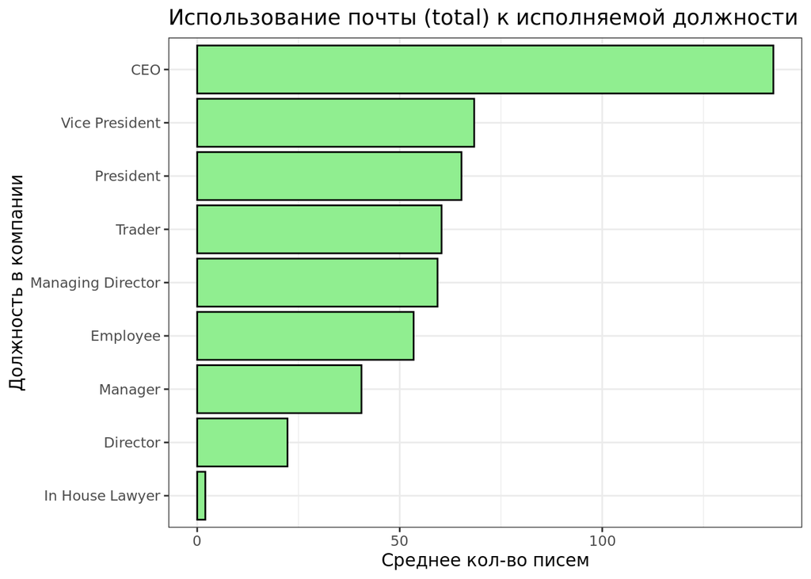

```r
ggplot(stats) +
  geom_col(aes(x = mean_total, y = forcats::fct_reorder(note, mean_total)), color = "black", fill = "lightgreen") +
  xlab("Среднее кол-во писем") +
  ylab("Должность в компании") +
  ggtitle("Использование почты (total) к исполняемой должности") +
  theme_bw()
```

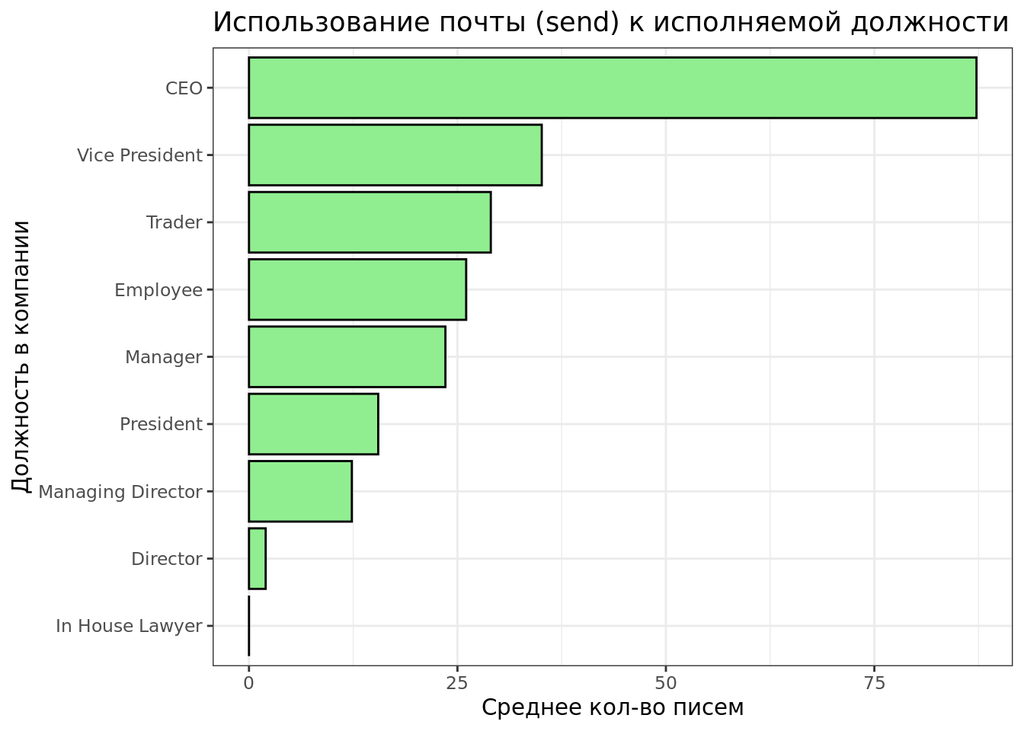

```r
ggplot(stats) +
  geom_col(aes(x = mean_send, y = forcats::fct_reorder(note, mean_send)), color = "black", fill = "lightgreen") +
  xlab("Среднее кол-во писем") +
  ylab("Должность в компании") +
  ggtitle("Использование почты (send) к исполняемой должности") +
  theme_bw()
```

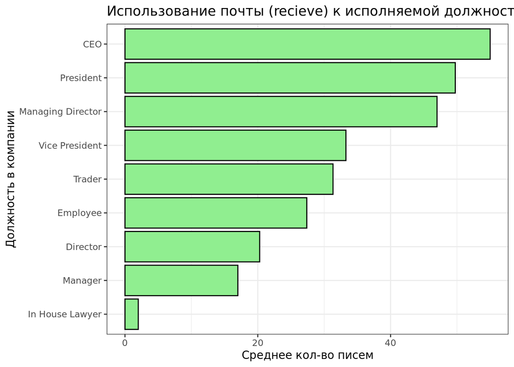

```r
ggplot(stats) +
  geom_col(aes(x = mean_get, y = forcats::fct_reorder(note, mean_get)), color = "black", fill = "lightgreen") +
  xlab("Среднее кол-во писем") +
  ylab("Должность в компании") +
  ggtitle("Использование почты (recieve) к исполняемой должности") +
  theme_bw()
```

## Место сотрудника в сети

```r
hw_net_get_vertex(net)
```

```
## [1] "John Lavorato"
```

**1) степень вершины**

Определим степень вершины (количество отправленных и полученных писем) у сотрудника John Lavorato.

```r
data.frame(name = V(net)$Name, degree = degree(net)) %>% dplyr::arrange(-degree) %>% dplyr::top_n(5)
```

```
##             name degree
## 1     Tana Jones    570
## 2 David Delainey    281
## 3  John Lavorato    262
## 4    Susan Scott    221
## 5    Mark Taylor    219
```

Получили значение degree = 262. John Lavorato находится на 3 месте из 95 сотрудников по показателю degree. В данном контексте это показывает, что John Lavorato достаточно часто использует в своей работе электронную почту.

**2) центральность по посредничеству**

Определим значение битвидности у John Lavorato.

```r
data.frame(name = V(net)$Name, betweenness = betweenness(net)) %>% dplyr::arrange(-betweenness) %>% dplyr::top_n(5)
```

```
##             name betweenness
## 1  John Lavorato   1376.3476
## 2 David Delainey    900.9489
## 3   Philip Allen    756.4957
## 4     Tana Jones    690.5613
## 5 Vince Kaminski    635.3757
```

Получили значение битвидности = 1376.3 и это самый больший показатель в нашей сети. Это означает, что через John Lavorato проходит наибольшее количество кратчайших путей от одного сотрудника до другого через электронную почту. Следовательно, через него проходит самый большой объём информации в компании.

Также, значимость данной вершины просматривается на уже приведённой выше визуализации, на которой величина вершин соответствует показателю битвидности. Вершина “John Lavorato” является самой крупной и находится в центре графа.

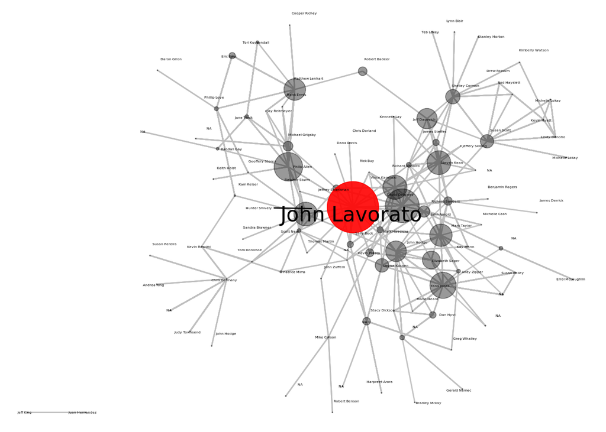

```r
ggraph(net) +
    geom_edge_link(color = "grey", alpha = 0.7) +
    geom_node_point(color = dplyr::case_when(V(net)$Name == "John Lavorato" ~ "red", TRUE ~ "black"),
                    size = betweenness(net)/70,
                    alpha = dplyr::case_when(V(net)$Name == "John Lavorato" ~ 0.9, TRUE ~ 0.4)) +
    geom_node_text(aes(label=Name,
                       size = dplyr::case_when(V(net)$Name == "John Lavorato" ~ 5, TRUE ~ 1)),
                   show.legend = FALSE, nudge_x = 0.1, nudge_y = 0.1, repel = TRUE)  +
  theme_void()
```

**3) идентификация сообщества**

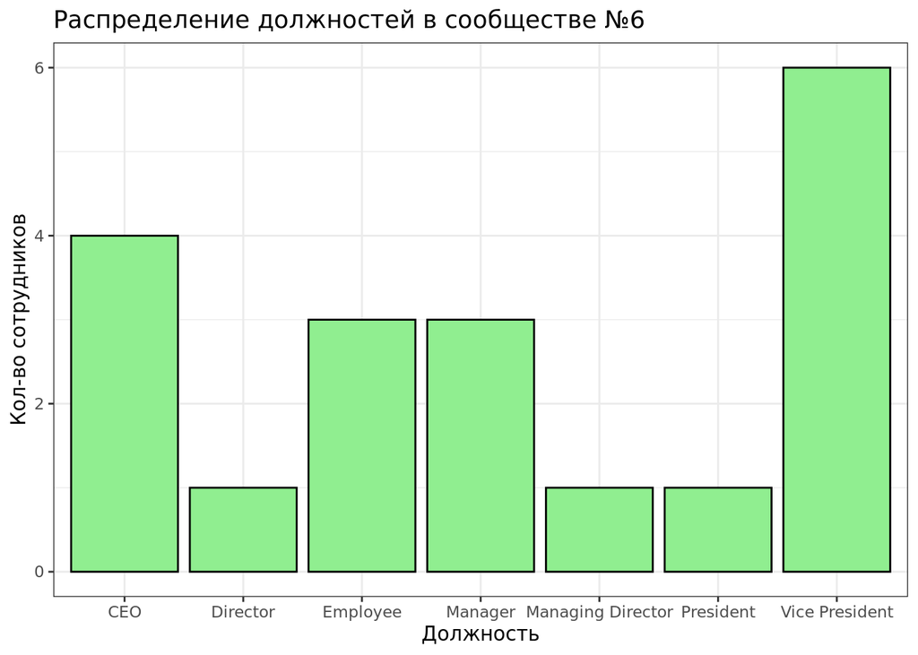

```r
vertices = data.frame(name = V(net)$Name, note = V(net)$Note, send = degree(net, mode = "out"), get = degree(net, mode = "in"), community = membership(coms_wt)[])

head_community_number = vertices %>% dplyr::filter(name == "John Lavorato")
head_community_number = head_community_number$community
vertices = vertices %>% dplyr::filter(community == head_community_number) %>% dplyr::filter(note != "NA")
vertices = vertices %>% dplyr::filter(note != "NA") %>% dplyr::mutate(note = str_extract(vertices$note, "[A-Za-z ]*[^,]"))

ggplot(vertices) +
  geom_bar(aes(note), color = "black", fill = "lightgreen") +
  xlab("Должность") +
  ylab("Кол-во сотрудников") +
  ggtitle(str_c("Распределение должностей в сообществе №", as.character(head_community_number))) +
  theme_bw()
```

Из данного графика можно сделать вывод, что John Lavorato находится в сообществе с людьми, исполняющими самые высокие должности в компании. Следовательно, John Lavorato тоже занимает высокую должность в компании.

Это можно проверить, посмотрев атрибут вершины, советующий его должности.

```r
dplyr::filter(data.frame(name = V(net)$Name, note = V(net)$Note), name == "John Lavorato")
```

```
##            name               note
## 1 John Lavorato CEO, Enron America
```

John Lavorato - CEO компании Enron America.

## Общие выводы

В процессе анализа сети email переписок сотрудников компании Enron были использованы различные меры центральности, ассортативность, несколько алгоритмов выделения сообществ, а также библиотеки для визуализации полученных результатов.

Во-первых, исходя из проведённого анализа можно сказать, что сотрудники компании достаточно часто используют электронную почту для коммуникации. Также, стоит заметить, что у сотрудников с высокой должностью прослеживается высокая центральность по посредничеству. Это можно легко объяснить тем, что сотрудники всегда должны осведомлять начальство о результатах своей работы, а начальство раздавать задания. Поэтому битвидность узлов растёт в соответствии с занимаемой должностью.

Во-вторых, в ходе анализа потока электронных писем удалось выявить 10 сообществ сотрудников с достаточно хорошим показателем модулярности. На визуализации сообществ видно, что распределены они достаточно равномерно и можно уверенно предположить, что полученные сообщества могут соответствовать реальному распределению сотрудников по командам, отделам или филиалам компании.

В-третьих, на основе предоставленных данных удалось определить положение определённого сотрудника (John Lavorato) в организации с помощью мер центральности и распределения по сообществам. Высокие показатели degree и betweenness, а также распределение в сообщество с сотрудниками высоких должностей помогли выяснить, что John Lavorato является крайне важным и высокопоставленным сотрудником в компании Enron.